# Food Images

#### Martin Krebs, Filip Brukner, Hugo Adamove

# Task

Classify fruits and vegetables in image dataset from https://www.kaggle.com/kritikseth/fruit-and-vegetable-image-recognition

# Dataset introduction

- data containing 3116 images of fruits and vegtables
- separated into 36 different classes (Apples, Bananas, etc.,)
- already split into test (10%), train (80%), validation (10%) images

# Data Sample

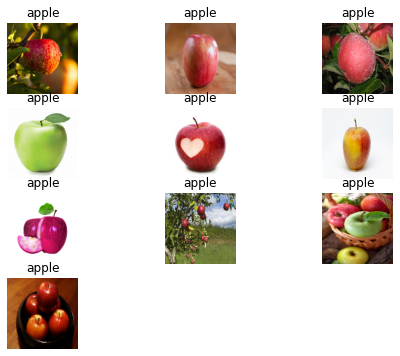

### Observation:

The majority of the apples in the dataset are red, this might cause quite poor performance on real-world data, as apples are quite ofter green or yellow.

# Data Analysis

## Class Distribution

```
<BarContainer object of 36 artists>
```

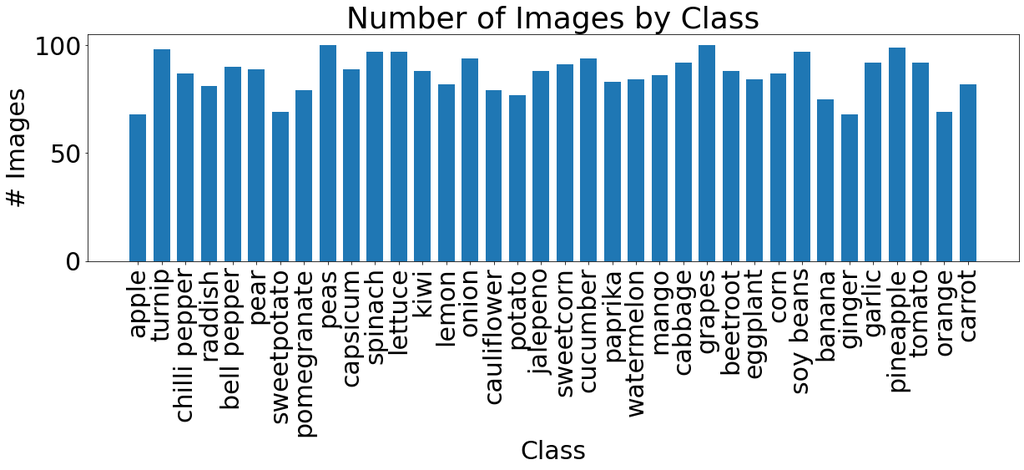

### Observation:

The individual classes are pretty uniformly distributed, which should prevent undesired bias.

## Class Properties - Mean

Calculating `np.mean` on images of Apples

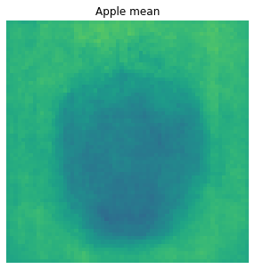

## Class Properties - Deviation

Calculating `np.std` on images of Pineapples

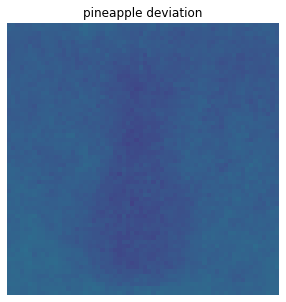

## Class Properties - Variance

Calculating `np.var` on images of Kiwi

[figure not shown]

# Class Eigen Images

Using PCA to find componensts, which describe each class the best

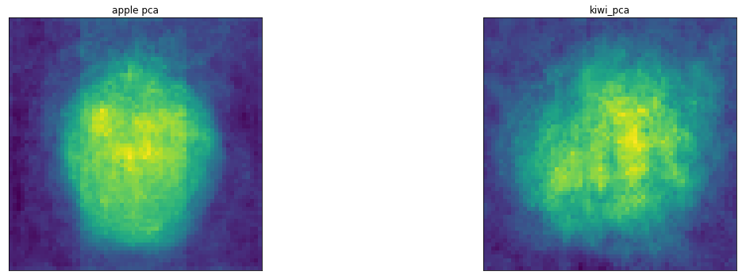

# Data Preprocessing

## Resizing

- The majority of the images in the dataset have different resolution and aspect ratio
- To train our ResNet model, image data is fed in N batches, which requires that all images are of uniform size
- We use `Resize` transform from `torchvision.transforms` to resize all images to uniform `256x256` size

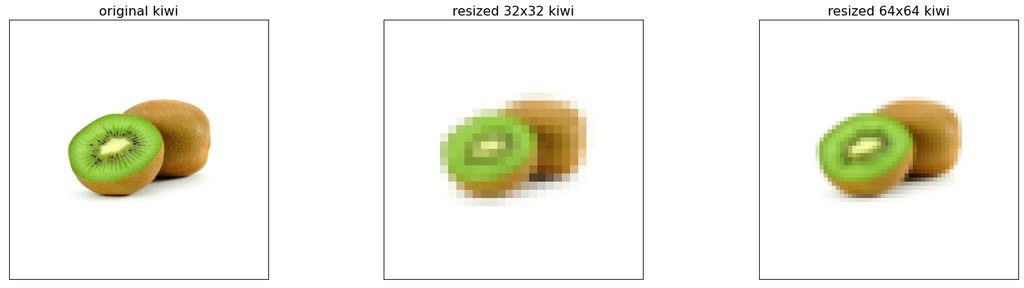

## Flipping

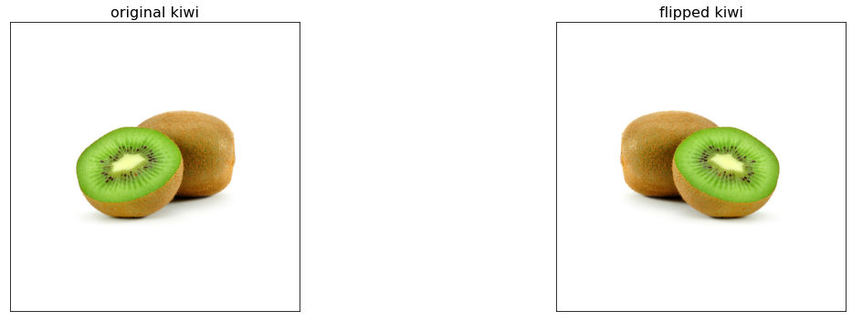

## Center Cropping

- The most important parts of the images are usually present in the center
- We perform a `CenterCrop` transform to cut off "uninteresting" parts
- This also brings our image size further down to `224x224` which is the required resolution for our model (ResNet)

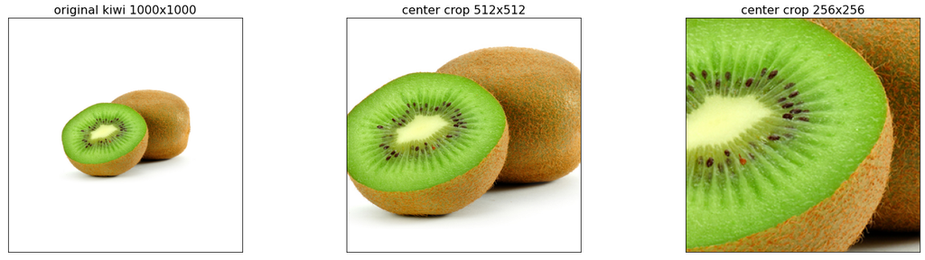

## Normalizing

- Normalizing an image is performed by subtracting the mean pixel value across all of the training data and dividing by the standard deviation
- This ensures that each pixel has a similar data distribution

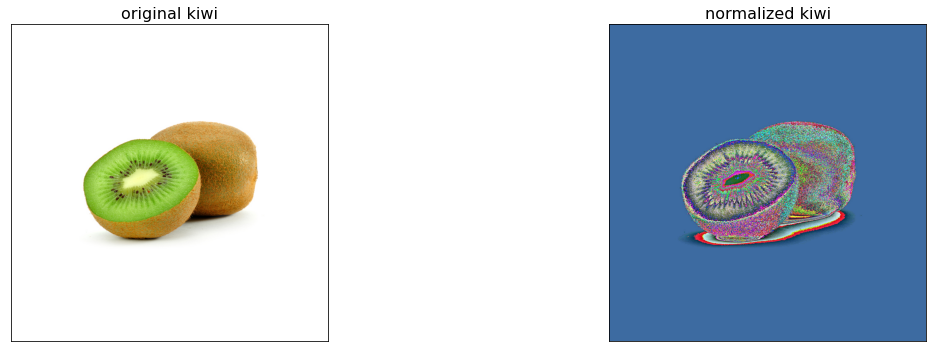

## Creating Preprocess Pipeline using `Compose`

```
data_transforms = {
    'train': transforms.Compose([
        transforms.RandomResizedCrop(224),
        transforms.RandomHorizontalFlip(), # helps fight the bias in input images
        transforms.ToTensor(),
        transforms.Normalize(mean=[0.485, 0.456, 0.406], std=[0.229, 0.224, 0.225])
    ]),
    'validation': transforms.Compose([
        transforms.Resize(256),
        transforms.CenterCrop(224),
        transforms.ToTensor(),
        transforms.Normalize(mean=[0.485, 0.456, 0.406], std=[0.229, 0.224, 0.225])
    ]),
}
```

# Applying the Pipeline on the Dataset

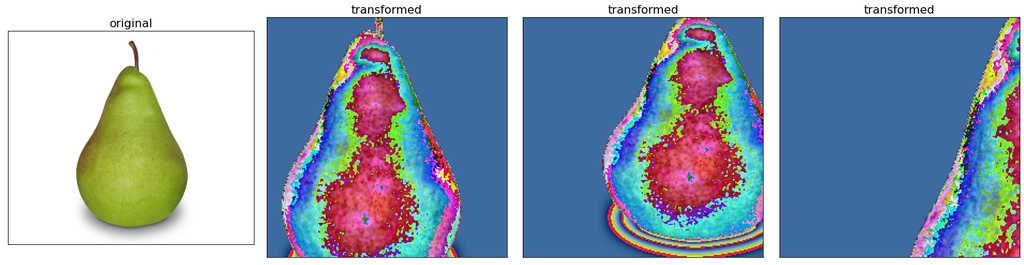

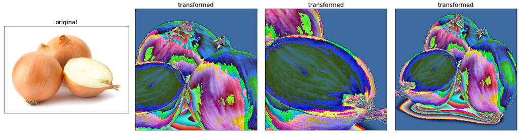